# ReproResProj1

Kevin Goldsmith

3/24/2019

## Reproducible Research Project 1

#### 1) Code for reading in the dataset and/or processing the data

Load the data

```r
fitdata<-read.csv("activity.csv")
```

Process/transform the data into a suitable format for analysis

```r
fitdata$date<-as.Date(as.character(fitdata$date),
                   format = "%Y-%m-%d")
fitdataNB<-na.omit(fitdata)
```

#### 2) Histogram of the total number of steps taken each day

Calculate the total number of steps taken per day

```r
library(plyr)
daydata<- ddply(fitdataNB,.(date),summarize,TotalSteps=sum(steps))
```

Make a histogram of the total number of steps taken each day

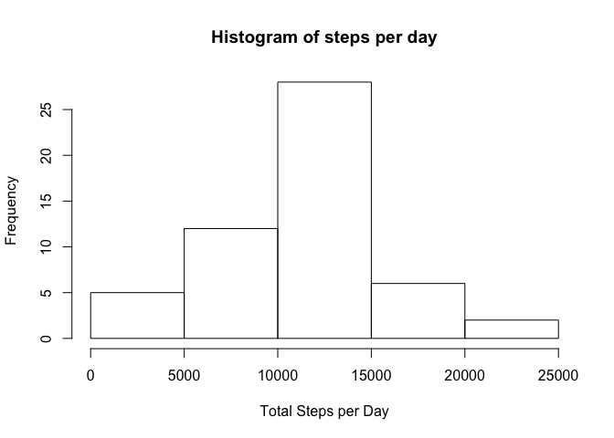

```r
hist(daydata$TotalSteps, main = "Histogram of steps per day", xlab = "Total Steps per Day")
```

#### 3) Mean and median number of steps taken each day

Calculate and report the mean and median of the total number of steps taken per day

```r
meansteps = mean(daydata$TotalSteps)
mediansteps = median(daydata$TotalSteps)
cat("Mean: ",  meansteps, "\nMedian: ", mediansteps)
```

```
## Mean:  10766.19
## Median:  10765
```

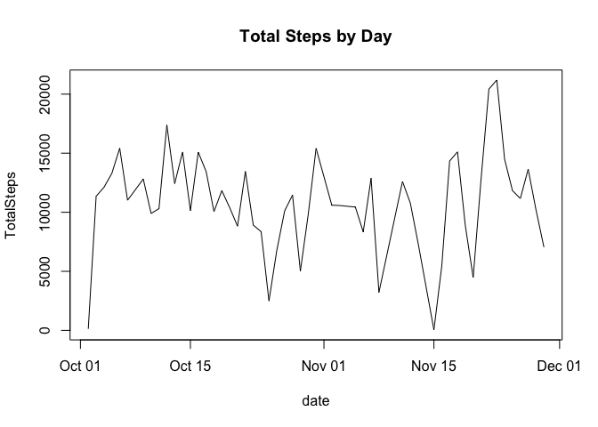

```r
plot(daydata, type = "l", main = "Total Steps by Day")
```

#### 5)The 5-minute interval that, on average, contains the maximum number of steps

Which 5-minute interval, on average across all the days in the dataset, contains the maximum number of steps?

```r
intervalavg<-ddply(fitdataNB, .(interval), summarize, AvgSteps = mean(steps))
maxsteps = which.max(intervalavg$AvgSteps)
cat("Higest average interval: ", intervalavg$interval[maxsteps])
```

```
## Higest average interval:  835
```

#### 6) Code to describe and show a strategy for imputing missing data

Calculate and report the total number of missing values in the dataset

```r
NAcount = sum(is.na(fitdata$steps))
print(NAcount)
```

```
## [1] 2304
```

Devise a strategy for filling in all of the missing values in the dataset. Use the mean for the 5-minute interval. Create a new dataset that is equal to the original dataset but with the missing data filled in.

```r
library(dplyr)
fitdata2<-fitdata %>% group_by(interval) %>% mutate(steps = ifelse(is.na(steps), mean(steps, na.rm = TRUE), steps)) %>% ungroup
daydata2<- ddply(fitdata2,.(date),summarize,TotalSteps=sum(steps))
```

#### 7) Histogram of the total number of steps taken each day after missing values are imputed

Make a histogram of the total number of steps taken each day

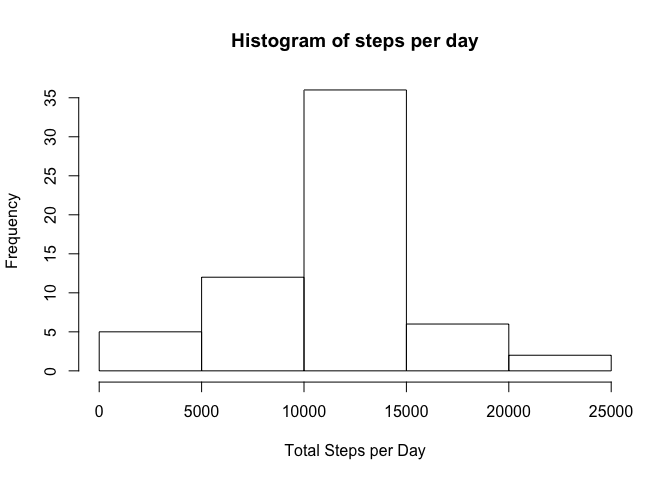

```r
hist(daydata2$TotalSteps, main = "Histogram of steps per day", xlab = "Total Steps per Day")
```

Calculate and report the mean and median total number of steps taken per day

```r
meansteps = mean(daydata2$TotalSteps)
mediansteps = median(daydata2$TotalSteps)
cat("Mean: ",  meansteps, "\nMedian: ", mediansteps)
```

```
## Mean:  10766.19
## Median:  10766.19
```

#### 8) Panel plot comparing the average number of steps taken per 5-minute interval across weekdays and weekends

Create a new factor variable in the dataset with two levels - “weekday” and “weekend”

```r
byweekday<-mutate(fitdata2,WD = factor(ifelse(weekdays(fitdata2$date) %in% c("Saturday", "Sunday"),"Weekend","Weekday")))
```

Make a panel plot containing a time series plot of the 5-minute interval and the average number of steps taken, averaged acrossed all weekdays or weekend days

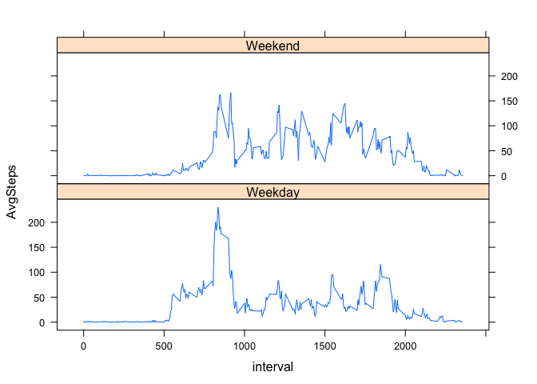

```r
library(lattice)
intervaldata<- ddply(byweekday,c(.(interval),.(WD)),summarize,AvgSteps=mean(steps))
xyplot(AvgSteps ~ interval | WD, data = intervaldata, layout = c(1,2), type = "l")
```